# Healthcare PGP

**DESCRIPTION**

Problem Statement NIDDK (National Institute of Diabetes and Digestive and Kidney Diseases) research creates knowledge about and treatments for the most chronic, costly, and consequential diseases. The dataset used in this project is originally from NIDDK. The objective is to predict whether or not a patient has diabetes, based on certain diagnostic measurements included in the dataset. Build a model to accurately predict whether the patients in the dataset have diabetes or not. Dataset Description The datasets consists of several medical predictor variables and one target variable (Outcome). Predictor variables includes the number of pregnancies the patient has had, their BMI, insulin level, age, and more.

## `Project Task: Week 1`

**Data Exploration:**

1. Perform descriptive analysis. Understand the variables and their corresponding values. On the columns below, a value of zero does not make sense and thus indicates missing value:

   ```
    • Glucose
    • BloodPressure
    • SkinThickness
    • Insulin
    • BMI
   ```

2. Visually explore these variables using histograms. Treat the missing values accordingly.
3. There are integer and float data type variables in this dataset. Create a count (frequency) plot describing the data types and the count of variables.

**Code:**

```python
# Importing all the required modules

import pandas as pd
import numpy as np
import matplotlib.pyplot as plt
import seaborn as sns
from sklearn import metrics
from sklearn.svm import SVC
from sklearn.metrics import roc_curve
from sklearn.metrics import roc_auc_score
from sklearn.model_selection import train_test_split
from sklearn.preprocessing import StandardScaler
from sklearn.linear_model import LogisticRegression
from sklearn.ensemble import RandomForestClassifier
from sklearn.tree import DecisionTreeClassifier
from sklearn.neighbors import KNeighborsClassifier
from sklearn.metrics import classification_report
from sklearn.model_selection import GridSearchCV
from sklearn.metrics import accuracy_score, confusion_matrix
import xgboost as xgb

import warnings
warnings.filterwarnings('ignore')
```

```python
# Reading the dataset in pandas dataframe
df= pd.read_csv('health care diabetes.csv')
```

```python
print("Dimension of the Data set is", df.shape)
print()
df.head()
```

```
Dimension of the Data set is (768, 9)
```

|  | Pregnancies | Glucose | BloodPressure | SkinThickness | Insulin | BMI | DiabetesPedigreeFunction | Age | Outcome |
| --- | --- | --- | --- | --- | --- | --- | --- | --- | --- |
| 0 | 6 | 148 | 72 | 35 | 0 | 33.6 | 0.627 | 50 | 1 |
| 1 | 1 | 85 | 66 | 29 | 0 | 26.6 | 0.351 | 31 | 0 |
| 2 | 8 | 183 | 64 | 0 | 0 | 23.3 | 0.672 | 32 | 1 |
| 3 | 1 | 89 | 66 | 23 | 94 | 28.1 | 0.167 | 21 | 0 |
| 4 | 0 | 137 | 40 | 35 | 168 | 43.1 | 2.288 | 33 | 1 |

```python
df.info()
```

```
<class 'pandas.core.frame.DataFrame'>
RangeIndex: 768 entries, 0 to 767
Data columns (total 9 columns):
 #   Column                    Non-Null Count  Dtype
---  ------                    --------------  -----
 0   Pregnancies               768 non-null    int64
 1   Glucose                   768 non-null    int64
 2   BloodPressure             768 non-null    int64
 3   SkinThickness             768 non-null    int64
 4   Insulin                   768 non-null    int64
 5   BMI                       768 non-null    float64
 6   DiabetesPedigreeFunction  768 non-null    float64
 7   Age                       768 non-null    int64
 8   Outcome                   768 non-null    int64
dtypes: float64(2), int64(7)
memory usage: 54.1 KB
```

```python
df.describe().transpose()
```

|  | count | mean | std | min | 25% | 50% | 75% | max |
| --- | --- | --- | --- | --- | --- | --- | --- | --- |
| Pregnancies | 768.0 | 3.845052 | 3.369578 | 0.000 | 1.00000 | 3.0000 | 6.00000 | 17.00 |
| Glucose | 768.0 | 120.894531 | 31.972618 | 0.000 | 99.00000 | 117.0000 | 140.25000 | 199.00 |
| BloodPressure | 768.0 | 69.105469 | 19.355807 | 0.000 | 62.00000 | 72.0000 | 80.00000 | 122.00 |
| SkinThickness | 768.0 | 20.536458 | 15.952218 | 0.000 | 0.00000 | 23.0000 | 32.00000 | 99.00 |
| Insulin | 768.0 | 79.799479 | 115.244002 | 0.000 | 0.00000 | 30.5000 | 127.25000 | 846.00 |
| BMI | 768.0 | 31.992578 | 7.884160 | 0.000 | 27.30000 | 32.0000 | 36.60000 | 67.10 |
| DiabetesPedigreeFunction | 768.0 | 0.471876 | 0.331329 | 0.078 | 0.24375 | 0.3725 | 0.62625 | 2.42 |
| Age | 768.0 | 33.240885 | 11.760232 | 21.000 | 24.00000 | 29.0000 | 41.00000 | 81.00 |
| Outcome | 768.0 | 0.348958 | 0.476951 | 0.000 | 0.00000 | 0.0000 | 1.00000 | 1.00 |

```python
df[['Glucose','BloodPressure','SkinThickness','Insulin','BMI']] = df[['Glucose','BloodPressure','SkinThickness','Insulin',
                                                                      'BMI']].replace(0,np.NaN)
```

```python
df.isnull().sum()
```

```
Pregnancies                   0
Glucose                       5
BloodPressure                35
SkinThickness               227
Insulin                     374
BMI                          11
DiabetesPedigreeFunction      0
Age                           0
Outcome                       0
dtype: int64
```

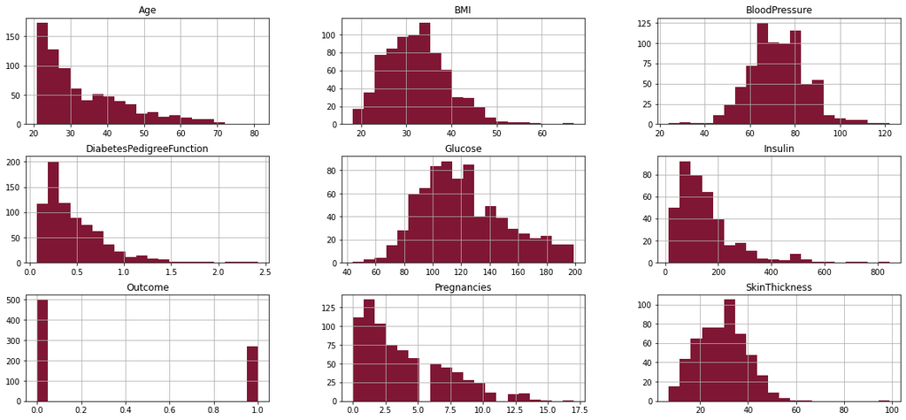

```python
df.hist(bins=20, figsize=(20,9), color='#7f1734');
```

```python
# Filling all the nan values of with the appropiate measure

df['Glucose'].fillna(df['Glucose'].mean(), inplace = True)
df['BloodPressure'].fillna(df['BloodPressure'].mean(), inplace = True)
df['SkinThickness'].fillna(df['SkinThickness'].median(), inplace = True)
df['Insulin'].fillna(df['Insulin'].median(), inplace = True)
df['BMI'].fillna(df['BMI'].median(), inplace = True)
```

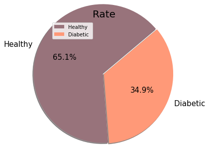

```python
# Checking for distribution of Outcome field

color = ('#98737B', '#FF9978')
plt.pie(df["Outcome"].value_counts(), data = df, explode=[0.028,0], labels=("Healthy", "Diabetic "),
        colors=color, autopct="%1.1f%%", shadow=True, startangle=400, radius=1.6, textprops = {"fontsize":15})
plt.title("Rate", loc='center',fontsize=20)
plt.legend()
plt.show();
```

[figure not shown]

```python
plt.figure(figsize=(8,6))
plt.style.use('dark_background')
df.dtypes.value_counts().plot(kind='barh',  color = ['#EA4335', '#34A853'])
plt.xlabel('Count of datatype of Variables')
plt.grid(b=False)
```

## `Project Task: Week 2`

**Data Exploration:**

1. Check the balance of the data by plotting the count of outcomes by their value. Describe your findings and plan future course of action.
2. Create scatter charts between the pair of variables to understand the relationships. Describe your findings.
3. Perform correlation analysis. Visually explore it using a heat map.

```
0    500
1    268
Name: Outcome, dtype: int64
```

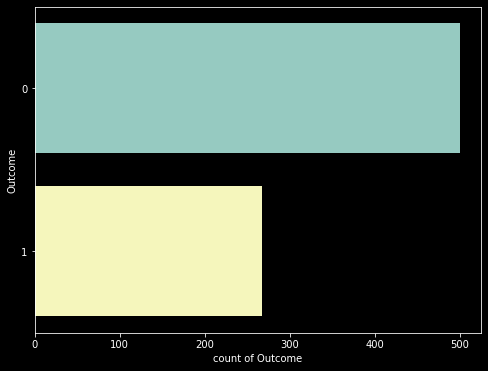

```python
print(df.Outcome.value_counts())
plt.figure(figsize=(8,6))
plt.style.use('dark_background')

sns.countplot(y=df['Outcome'], data=df)
plt.xlabel("count of Outcome")
plt.ylabel("Outcome")
plt.grid(b=False)
```

**Observation:**

> The above graph shows that the data is biased towards datapoints having outcome value as 0 where it means that diabetes was not present actually. The number of non-diabetics is almost twice the number of diabetic patients

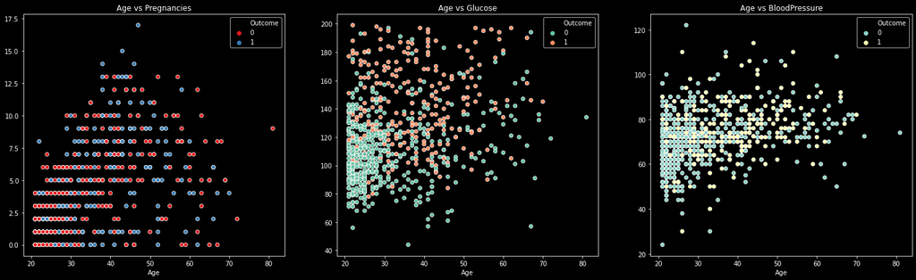

```python
fig, axes = plt.subplots(1, 3, figsize=(25,7))

sns.scatterplot(x="Age", y="Pregnancies", hue="Outcome",ax = axes[0],data=df, palette='Set1')
axes[0].set_title('Age vs Pregnancies')
axes[0].set_ylabel('')
axes[0].grid(b=False)

sns.scatterplot(x="Age", y="Glucose", hue="Outcome",ax = axes[1],data=df, palette='Set2')
axes[1].set_title('Age vs Glucose')
axes[1].set_ylabel('')
axes[1].grid(b=False, )

sns.scatterplot(x="Age", y="BloodPressure", hue="Outcome",ax = axes[2],data=df, palette='Set3')
axes[2].set_title('Age vs BloodPressure')
axes[2].set_ylabel('');
axes[2].grid(b=False)
```

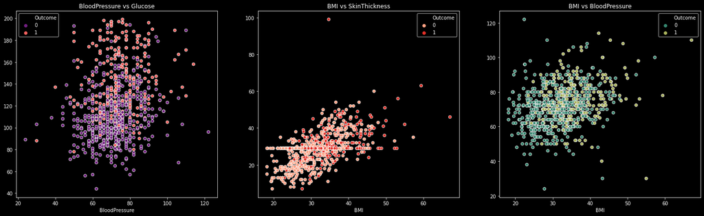

```python
fig, axes = plt.subplots(1, 3, figsize=(25,7))

sns.scatterplot(x="BloodPressure", y="Glucose", hue="Outcome",ax = axes[0],data=df, palette='magma')
axes[0].set_title('BloodPressure vs Glucose')
axes[0].set_ylabel('')
axes[0].grid(b=False)

sns.scatterplot(x="BMI", y="SkinThickness", hue="Outcome",ax = axes[1],data=df, palette='Reds')
axes[1].set_title('BMI vs SkinThickness')
axes[1].set_ylabel('')
axes[1].grid(b=False)

sns.scatterplot(x="BMI", y="BloodPressure", hue="Outcome",ax = axes[2],data=df, palette='gist_earth')
axes[2].set_title('BMI vs BloodPressure')
axes[2].set_ylabel('');
axes[2].grid(b=False)
```

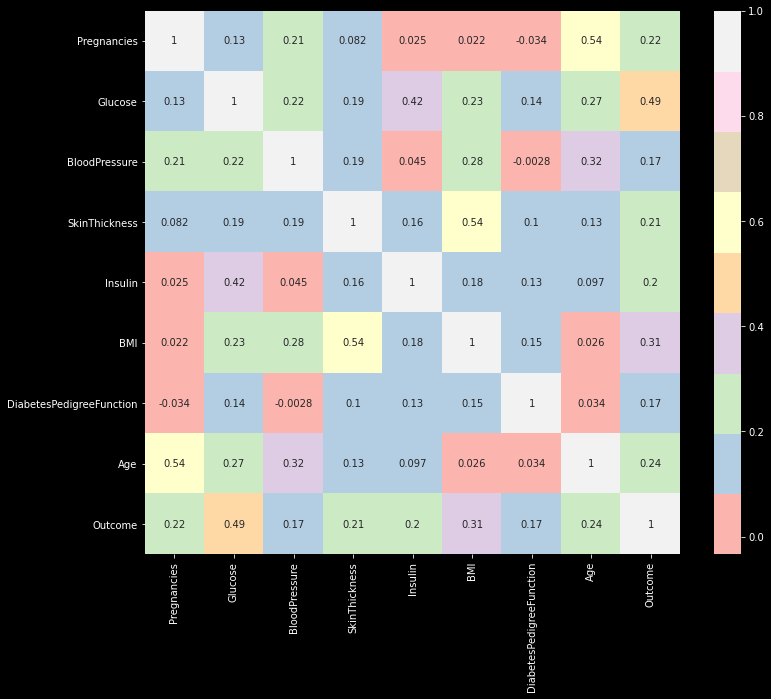

```python
plt.figure(figsize=(12,10))
sns.heatmap(df.corr(), cmap='Pastel1', annot=True);
```